# Test Questions (ds4psy)

Hansjörg Neth, SPDS, uni.kn

2018 05 23

# Course Coordinates

[figure not shown]

- Taught at the [University of Konstanz](https://www.uni-konstanz.de/) by [Hansjörg Neth](http://neth.de/) (h.neth@uni.kn, [SPDS](https://www.spds.uni-konstanz.de/), office D507).
- Spring/summer 2018: Mondays, 13:30–15:00, C511 (from 2018.04.16 to 2018.07.16)
- Links to [ZeUS](https://zeus.uni-konstanz.de:443/hioserver/pages/startFlow.xhtml?_flowId=showEvent-flow&unitId=5101&termYear=2018&termTypeValueId=1&navigationPosition=hisinoneLehrorganisation,examEventOverviewOwn) and [Ilias](https://ilias.uni-konstanz.de/ilias/goto_ilias_uni_crs_758039.html)

# Test Questions

This file contains practice and test questions suited to test your skills and understanding.

## 3: Data visualisation

```r
library(tidyverse)  # dplyr, ggplot
```

Note: The chapter does primarily introduce visualizations (with `ggplot`), but not yet data transformations (with `dplyr`).

### Using `mtcars` data

```r
## Data to use:
?mtcars
# mtcars

## (0) Convert into a tibble:
df <- as_tibble(rownames_to_column(mtcars, var = "model"))
df$cyl <- factor(df$cyl)
df$am <- factor(df$am)
df
```

```
# A tibble: 32 x 12
               model   mpg    cyl  disp    hp  drat    wt  qsec    vs
               <chr> <dbl> <fctr> <dbl> <dbl> <dbl> <dbl> <dbl> <dbl>
 1         Mazda RX4  21.0      6 160.0   110  3.90 2.620 16.46     0
 2     Mazda RX4 Wag  21.0      6 160.0   110  3.90 2.875 17.02     0
 3        Datsun 710  22.8      4 108.0    93  3.85 2.320 18.61     1
 4    Hornet 4 Drive  21.4      6 258.0   110  3.08 3.215 19.44     1
 5 Hornet Sportabout  18.7      8 360.0   175  3.15 3.440 17.02     0
 6           Valiant  18.1      6 225.0   105  2.76 3.460 20.22     1
 7        Duster 360  14.3      8 360.0   245  3.21 3.570 15.84     0
 8         Merc 240D  24.4      4 146.7    62  3.69 3.190 20.00     1
 9          Merc 230  22.8      4 140.8    95  3.92 3.150 22.90     1
10          Merc 280  19.2      6 167.6   123  3.92 3.440 18.30     1
# ... with 22 more rows, and 3 more variables: am <fctr>, gear <dbl>,
#   carb <dbl>
```

```r
## (1) Distribution of mpg: ----
range(df$mpg)
```

```
[1] 10.4 33.9
```

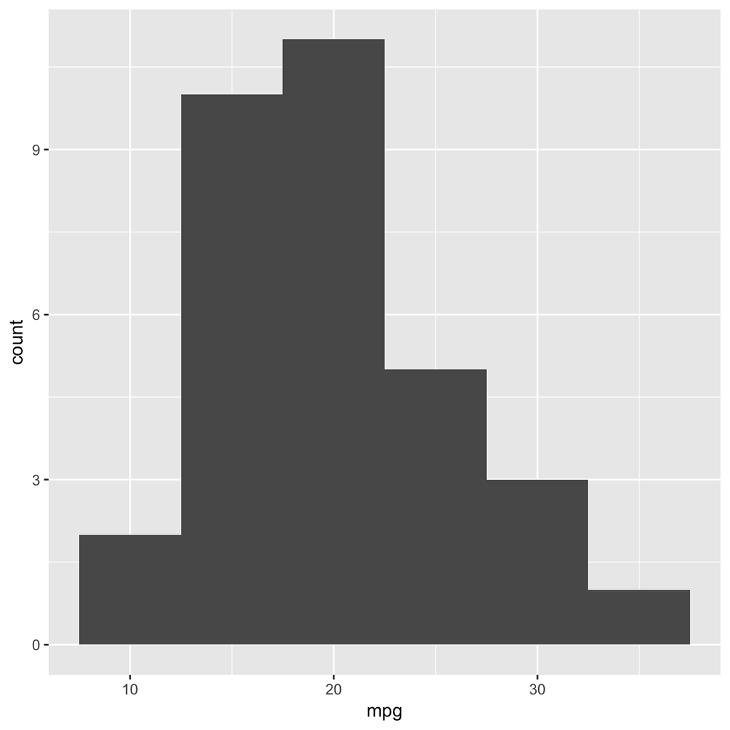

```r
ggplot(df, aes(x = mpg)) +
  geom_histogram(binwidth = 5)
```

```r
## (2) Group means and boxplot: Mean mpg by cylinder: ----

df %>%
  group_by(cyl) %>%
  summarise(n = n(),
            md_mpg = median(mpg),
            mn_mpg = mean(mpg)
            )
```

```
# A tibble: 3 x 4
     cyl     n md_mpg   mn_mpg
  <fctr> <int>  <dbl>    <dbl>
1      4    11   26.0 26.66364
2      6     7   19.7 19.74286
3      8    14   15.2 15.10000
```

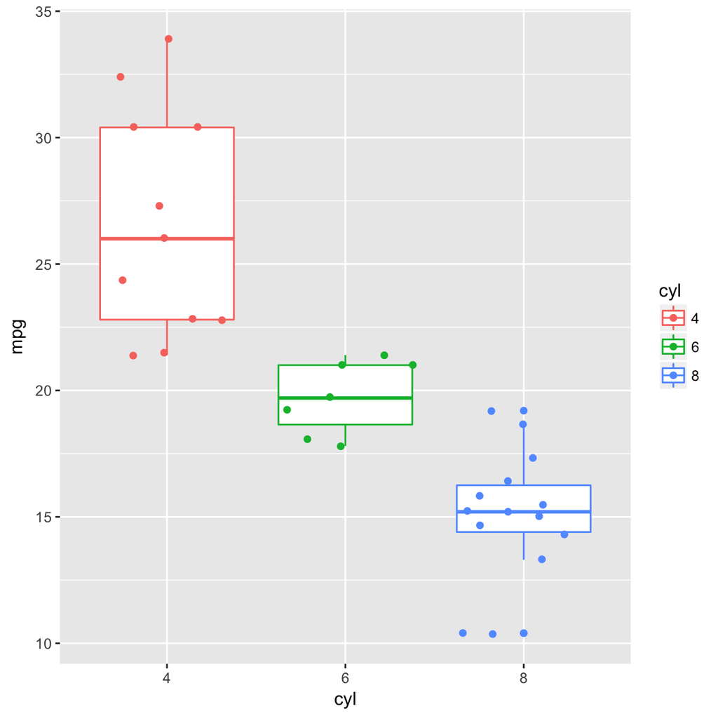

```r
ggplot(df, aes(x = cyl, y = mpg, color = cyl)) +
  geom_boxplot() +
  # geom_violin() +
  geom_jitter()
```

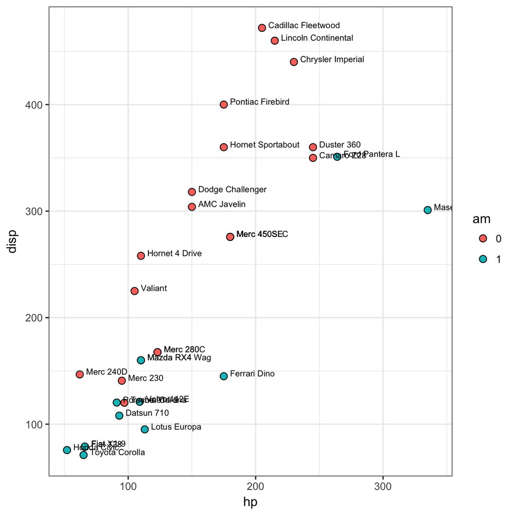

```r
## (3) Scatterplot: ----

## Show value of `disp` (on y-axis) by `hp` (on x-axis), grouped by `am`:
ggplot(df, aes(x = hp, y = disp, fill = am)) +
  geom_point(shape = 21, size = 2.5) +
  # geom_smooth() +
  geom_text(aes(label = model), size = 2.5, vjust = 0, hjust = 0, nudge_x = 5) +
  theme_bw()
```

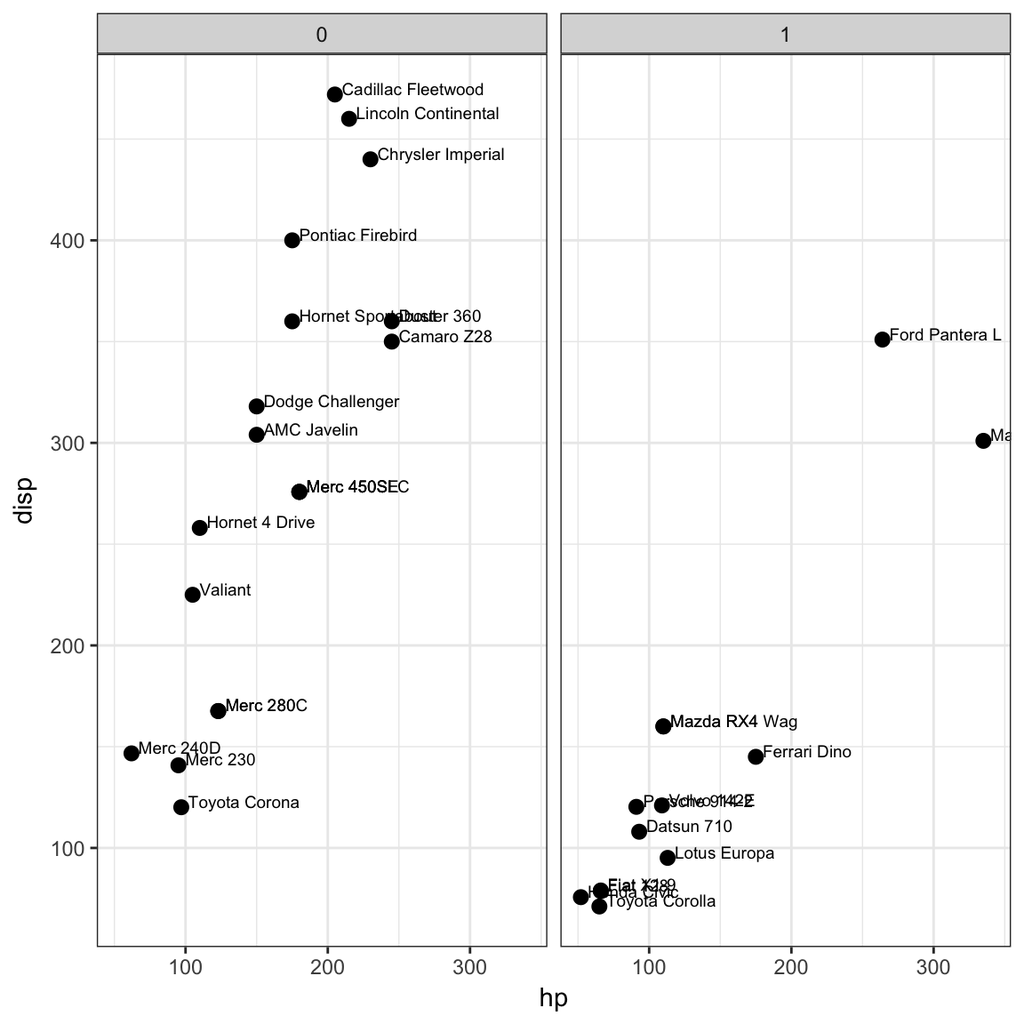

```r
## Alternative (using facets):
ggplot(df, aes(x = hp, y = disp)) +
  facet_wrap(~am) +
  geom_point(size = 2.5) +
  # geom_smooth() +
  geom_text(aes(label = model), size = 2.5, vjust = 0, hjust = 0, nudge_x = 5) +
  theme_bw()
```

```r
## Conclusions: ----
# - There is a positive correlation between horsepower and displacement
#   (for both types of transmission).
# - outliers: Ford Pantera L and Maserati
#             have more hp and disp than other cars with manual transmission.
```

#### Tasks involved

- Plot distribution (histogram)
- Descriptive group measures (count, mean, SD)
- Plot raw data and group means (boxplot)
- Plot scatterplot of 2 continuous variables
- Interpret and draw conclusions

Bonus: Label each bar with the number of cases (1) and adjust plot title and caption (1).

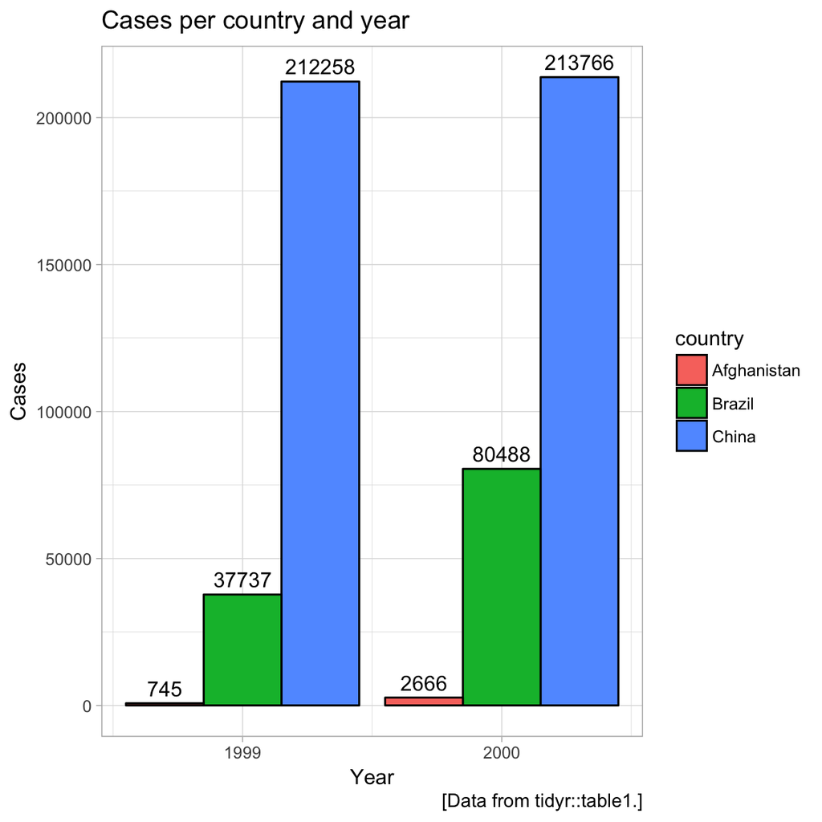

### Own data: German election results

Create tibble and then visualize election results, which are given as a table:

| Party: | Share 2017: | Share 2013: |
| --- | --- | --- |
| CDU/CSU | 33% | 41.5% |
| SPD | 20.5% | 25.7% |
| others | ? | ? |

```
    party share
1 CDU/CSU 0.330
2     SPD 0.205
3  others 0.465
```

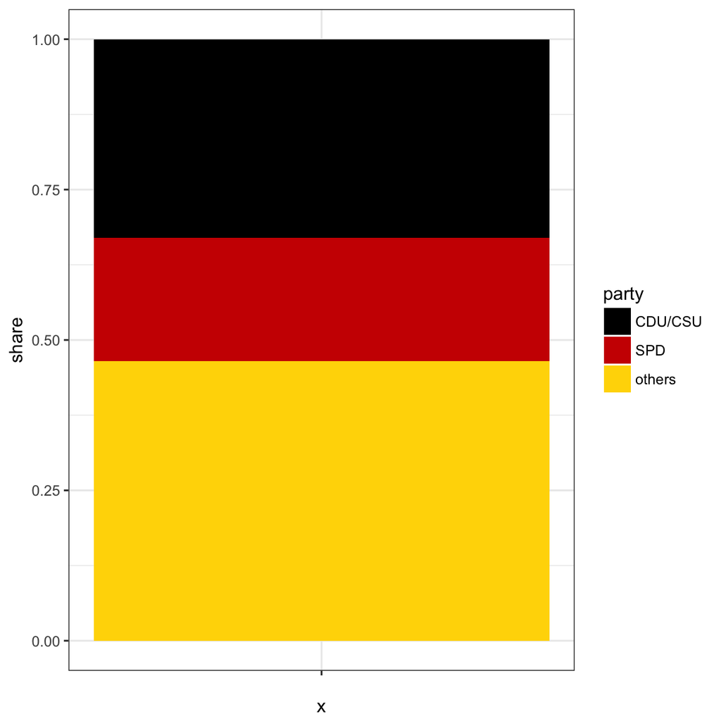

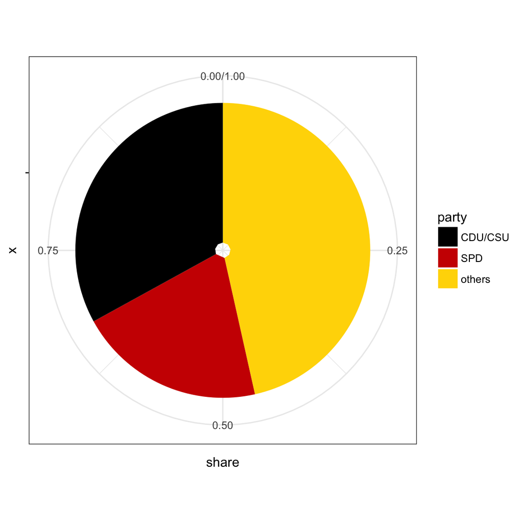

- Create a data frame or tibble
- Plot bar chart (with `stat = "identity"`)
- Create pie chart (with `coord_polar`)

## 5: Data transformation

```r
library(tidyverse)    # dplyr
library(nycflights13) # data
```

### Compute true flight duration

Using the `flights` dataset: - Compute a variable `true_duration` as the duration of each flight (in minutes) from its `dep_time` and `arr_time`. - How does it relate to the `air_time` variable in the data set? (Plot the relationship between both variables.)

```r
compute_duration <- function(dep_min, arr_min) {

  dur <- NA # initialize

  # Distinguish between 2 cases:
  if (dep_min < arr_min) {  # dep before arr (i.e., same day):
    dur <- arr_min - dep_min
  } else { # dep later than arr (i.e., different days):
    dur <- (arr_min + 24 * 60) - dep_min
  }

  return(dur)

}

# Check for vectors:
dep <- seq(0, 24*60, by = +15)
arr <- seq(24*60, 0, by = -15)

# compute_duration(dep, arr)
# ???: How to apply a function to each pair of values of 2 vectors/columns?

d <- flights %>%
  filter(origin == "JFK") %>%  # to reduce size of dataset
  select(dep_time, arr_time, air_time) %>%
  mutate(dep_time_min = ((dep_time %/% 100) * 60) + (dep_time %% 100),
         arr_time_min = ((arr_time %/% 100) * 60) + (arr_time %% 100),
         # true_duration = compute_duration(dep_time_min, arr_time_min),
         true_duration = arr_time_min - dep_time_min) %>%
  filter(air_time > 0, true_duration > 0)

p <- ggplot(d, (aes(x = air_time, y = true_duration))) +
  geom_point(alpha = 1/4) +
  geom_abline(intercept = 0, slope = 1, linetype = 2, size = 1, color = "red3") +
  theme_bw()
```

#### Notes

- The `dep_time` and `arr_time` are specified in terms of hour and minutes. As an hour contains 60 minutes (rather than 100), we first use modular arithmetic to transform both variables into a metric of minutes (see variables `dep_time_min` and `arr_time_min`).
- For flights departing and arriving on the same day, we can simply subtract `dep_time_min` from `arr_time_min` to obtain `true_duration`. However, if a flight departs before and arrives after midnight (i.e., arrives on the next day), this measure would yield a negative result. To correct for this, we need to add 24 hours (24 times 60 minutes) to `arr_time` whenever `arr_time` is before (or smaller than) `dep_time`. [This assumes that there are no flights exceeding 24 hours.]
- Seems too difficult at this stage, as it requires *conditional execution* (for flights departing and arriving on the same vs. different days) and/or *functions*.

In chapter 16 (Dates and times: http://r4ds.had.co.nz/dates-and-times.html), this problem is solved by introducing a Boolean variable for `overnight` flights and re-computing `air_time` by subtracting date-time objects (as intervals).

### Identifying outliers

#### Definition

Let’s define an *outlier* as someone deviating by more than 2 SD (in some metric) from the mean of a reference group. Depending on the reference group, outliers can be computed in defined in 2 ways:

1. relative to *overall* mean and SD;
2. relative to *group* mean and SD.

```
[1] 175.051
```

#### Tasks

A. Create 2 variables for both types of outliers.

B. Identify people who are outliers relative to *both* the entire poulation *and* to their own sex.

C. Identify people (men and women) who are *not* outliers relative to the entire population, but *are* outliers relative to their own sex. (As men are taller than women on average, these are tall women and small men.)

D. Visualize the overall distribution of `height`, its distribution by `sex`, and the raw data values for both types of outliers (by `sex`).

#### Solution

To identify both groups, we first need to compute 2 outlier variables: One for the entire population and one for each subgroup (based on people’s `sex`).

```
# A tibble: 1,000 x 9
# Groups:   sex [2]
      id    sex height mn_height sd_height out_height mn_sex_height
   <chr> <fctr>  <dbl>     <dbl>     <dbl>      <lgl>         <dbl>
 1   p.1      0    162   175.051   12.5487      FALSE      169.1203
 2   p.2      1    170   175.051   12.5487      FALSE      181.1501
 3   p.3      0    180   175.051   12.5487      FALSE      169.1203
 4   p.4      1    189   175.051   12.5487      FALSE      181.1501
 5   p.5      1    164   175.051   12.5487      FALSE      181.1501
 6   p.6      0    168   175.051   12.5487      FALSE      169.1203
 7   p.7      1    171   175.051   12.5487      FALSE      181.1501
 8   p.8      1    158   175.051   12.5487      FALSE      181.1501
 9   p.9      1    183   175.051   12.5487      FALSE      181.1501
10  p.10      0    168   175.051   12.5487      FALSE      169.1203
# ... with 990 more rows, and 2 more variables: sd_sex_height <dbl>,
#   out_sex_height <lgl>
```

```
# A tibble: 18 x 9
# Groups:   sex [2]
      id    sex height mn_height sd_height out_height mn_sex_height
   <chr> <fctr>  <dbl>     <dbl>     <dbl>      <lgl>         <dbl>
 1  p.91      0    138   175.051   12.5487       TRUE      169.1203
 2 p.116      0    140   175.051   12.5487       TRUE      169.1203
 3 p.130      1    204   175.051   12.5487       TRUE      181.1501
 4 p.163      1    203   175.051   12.5487       TRUE      181.1501
 5 p.165      0    144   175.051   12.5487       TRUE      169.1203
 6 p.249      1    207   175.051   12.5487       TRUE      181.1501
 7 p.311      0    141   175.051   12.5487       TRUE      169.1203
 8 p.355      1    207   175.051   12.5487       TRUE      181.1501
 9 p.366      1    209   175.051   12.5487       TRUE      181.1501
10 p.505      0    141   175.051   12.5487       TRUE      169.1203
11 p.508      1    208   175.051   12.5487       TRUE      181.1501
12 p.592      0    143   175.051   12.5487       TRUE      169.1203
13 p.626      0    204   175.051   12.5487       TRUE      169.1203
14 p.690      0    145   175.051   12.5487       TRUE      169.1203
15 p.692      1    204   175.051   12.5487       TRUE      181.1501
16 p.693      1    205   175.051   12.5487       TRUE      181.1501
17 p.717      0    145   175.051   12.5487       TRUE      169.1203
18 p.824      1    218   175.051   12.5487       TRUE      181.1501
# ... with 2 more variables: sd_sex_height <dbl>, out_sex_height <lgl>
```

```
# A tibble: 25 x 9
# Groups:   sex [2]
      id    sex height mn_height sd_height out_height mn_sex_height
   <chr> <fctr>  <dbl>     <dbl>     <dbl>      <lgl>         <dbl>
 1   p.8      1    158   175.051   12.5487      FALSE      181.1501
 2  p.49      0    196   175.051   12.5487      FALSE      169.1203
 3 p.176      1    159   175.051   12.5487      FALSE      181.1501
 4 p.190      1    158   175.051   12.5487      FALSE      181.1501
 5 p.196      0    196   175.051   12.5487      FALSE      169.1203
 6 p.243      0    195   175.051   12.5487      FALSE      169.1203
 7 p.246      1    157   175.051   12.5487      FALSE      181.1501
 8 p.247      0    199   175.051   12.5487      FALSE      169.1203
 9 p.308      0    193   175.051   12.5487      FALSE      169.1203
10 p.342      0    199   175.051   12.5487      FALSE      169.1203
# ... with 15 more rows, and 2 more variables: sd_sex_height <dbl>,
#   out_sex_height <lgl>
```

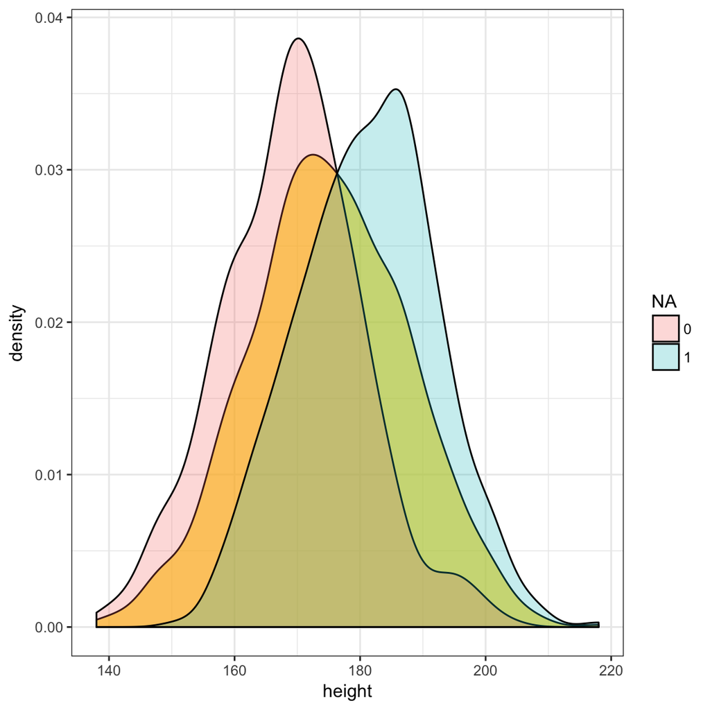

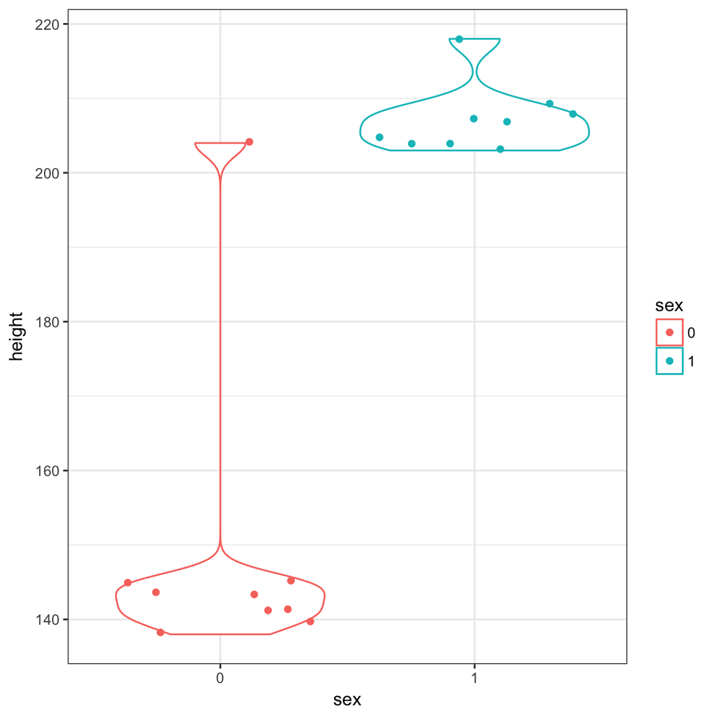

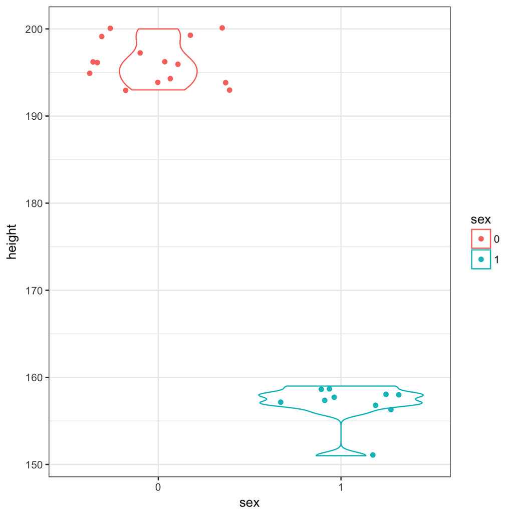

[This file last updated on 2018-05-24 07:21:58 by [hn](http://neth.de/).]